# DensityReport

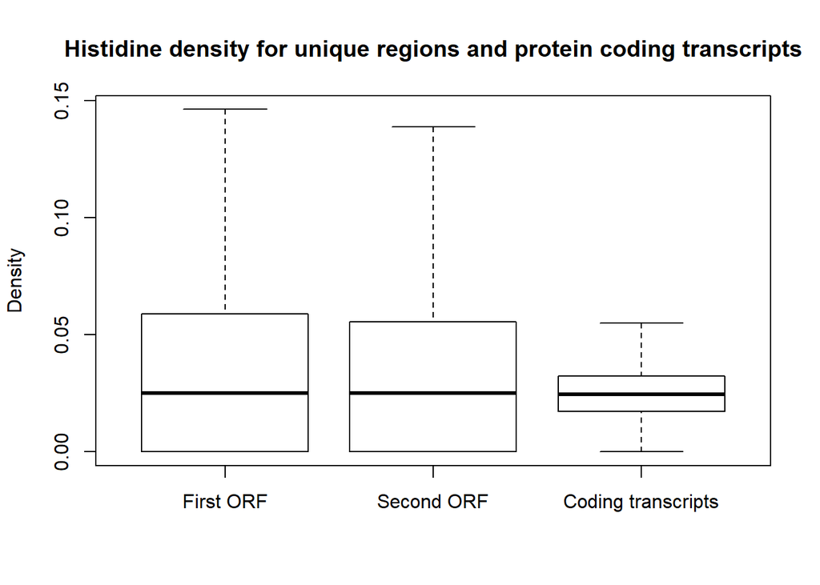

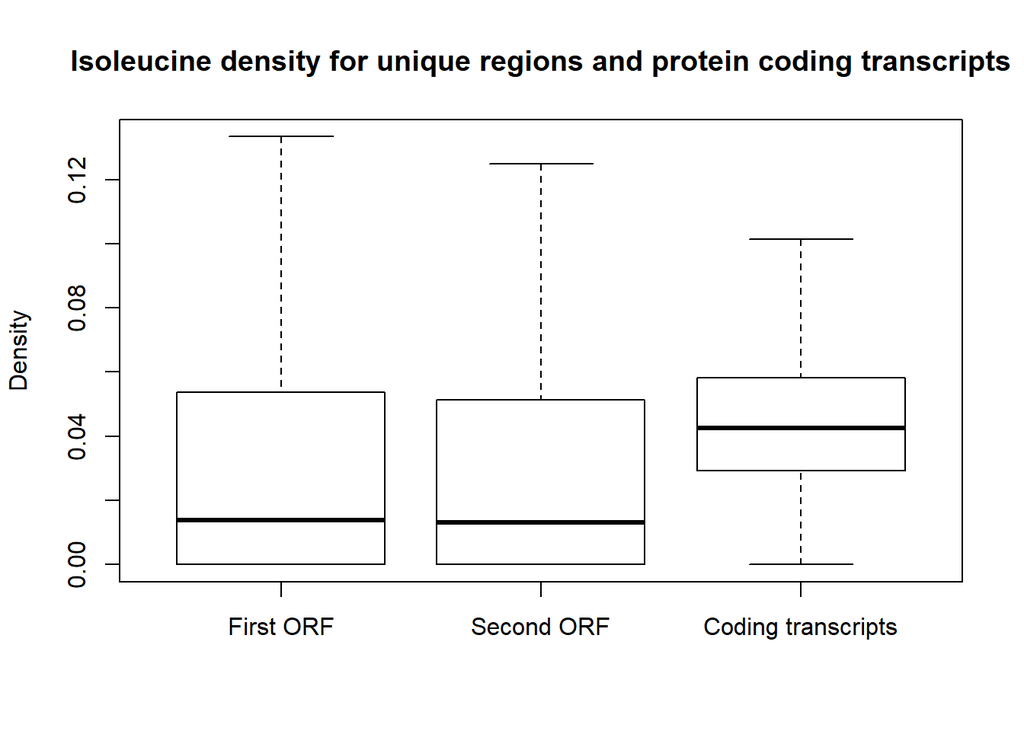

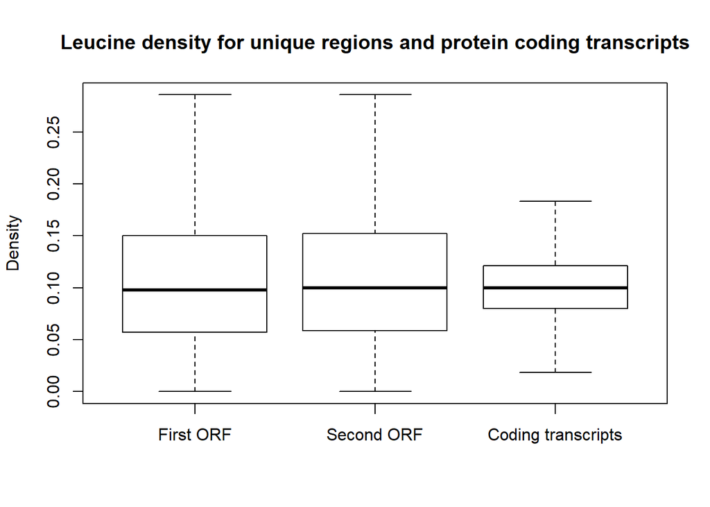

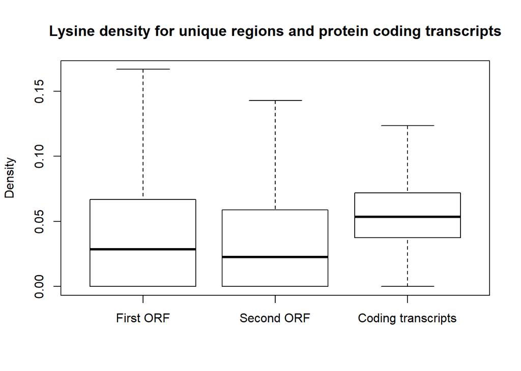

[8 more figures not shown]

### T-test between unique Protein Regions in first ORF and unique Protein Regions in second ORF:

```
## Alananine:
```

```
##
##  Welch Two Sample t-test
##
## data:  NMDMousedensitiesA[[1]] and NMDMousedensitiesA[[2]]
## t = 0.60413, df = 2971.4, p-value = 0.5458
## alternative hypothesis: true difference in means is not equal to 0
## 95 percent confidence interval:
##  -0.002962686  0.005601327
## sample estimates:
##  mean of x  mean of y
## 0.06732470 0.06600538
```

```
## Arginine
```

```
##
##  Welch Two Sample t-test
##
## data:  NMDMousedensitiesR[[1]] and NMDMousedensitiesR[[2]]
## t = 0.18657, df = 2964.3, p-value = 0.852
## alternative hypothesis: true difference in means is not equal to 0
## 95 percent confidence interval:
##  -0.003920301  0.004744811
## sample estimates:
##  mean of x  mean of y
## 0.07196380 0.07155155
```

```
## Asparagine
```

```
##
##  Welch Two Sample t-test
##
## data:  NMDMousedensitiesN[[1]] and NMDMousedensitiesN[[2]]
## t = 0.56872, df = 2964.2, p-value = 0.5696
## alternative hypothesis: true difference in means is not equal to 0
## 95 percent confidence interval:
##  -0.001823617  0.003313693
## sample estimates:
##  mean of x  mean of y
## 0.02335837 0.02261333
```

```
## Aspartic acid
```

```
##
##  Welch Two Sample t-test
##
## data:  NMDMousedensitiesD[[1]] and NMDMousedensitiesD[[2]]
## t = 0.7789, df = 2956.4, p-value = 0.4361
## alternative hypothesis: true difference in means is not equal to 0
## 95 percent confidence interval:
##  -0.001577991  0.003657902
## sample estimates:
##  mean of x  mean of y
## 0.02797032 0.02693037
```

```
## Cysteine
```

```
##
##  Welch Two Sample t-test
##
## data:  NMDMousedensitiesC[[1]] and NMDMousedensitiesC[[2]]
## t = -1.6486, df = 2987.8, p-value = 0.09933
## alternative hypothesis: true difference in means is not equal to 0
## 95 percent confidence interval:
##  -0.0059002210  0.0005102559
## sample estimates:
##  mean of x  mean of y
## 0.03989246 0.04258745
```

```
## Glutamine
```

```
##
##  Welch Two Sample t-test
##
## data:  NMDMousedensitiesQ[[1]] and NMDMousedensitiesQ[[2]]
## t = 1.7098, df = 2979.7, p-value = 0.08741
## alternative hypothesis: true difference in means is not equal to 0
## 95 percent confidence interval:
##  -0.0004145995  0.0060641137
## sample estimates:
##  mean of x  mean of y
## 0.04471905 0.04189430
```

```
## Glycine
```

```
##
##  Welch Two Sample t-test
##
## data:  NMDMousedensitiesG[[1]] and NMDMousedensitiesG[[2]]
## t = -0.66547, df = 2987.6, p-value = 0.5058
## alternative hypothesis: true difference in means is not equal to 0
## 95 percent confidence interval:
##  -0.006088937  0.003003144
## sample estimates:
##  mean of x  mean of y
## 0.07105961 0.07260250
```

```
## Glutamic acid
```

```
##
##  Welch Two Sample t-test
##
## data:  NMDMousedensitiesE[[1]] and NMDMousedensitiesE[[2]]
## t = 1.0768, df = 2968.6, p-value = 0.2816
## alternative hypothesis: true difference in means is not equal to 0
## 95 percent confidence interval:
##  -0.001436365  0.004936111
## sample estimates:
##  mean of x  mean of y
## 0.04054541 0.03879553
```

```
## Histidine
```

```
##
##  Welch Two Sample t-test
##
## data:  NMDMousedensitiesH[[1]] and NMDMousedensitiesH[[2]]
## t = 0.86604, df = 2964.9, p-value = 0.3865
## alternative hypothesis: true difference in means is not equal to 0
## 95 percent confidence interval:
##  -0.001672130  0.004317769
## sample estimates:
##  mean of x  mean of y
## 0.03558649 0.03426367
```

```
## Isoleucine
```

```
##
##  Welch Two Sample t-test
##
## data:  NMDMousedensitiesI[[1]] and NMDMousedensitiesI[[2]]
## t = 0.93113, df = 2968.9, p-value = 0.3519
## alternative hypothesis: true difference in means is not equal to 0
## 95 percent confidence interval:
##  -0.001619629  0.004548983
## sample estimates:
##  mean of x  mean of y
## 0.03186555 0.03040087
```

```
## Leucine
```

```
##
##  Welch Two Sample t-test
##
## data:  NMDMousedensitiesL[[1]] and NMDMousedensitiesL[[2]]
## t = -1.0304, df = 2984.8, p-value = 0.3029
## alternative hypothesis: true difference in means is not equal to 0
## 95 percent confidence interval:
##  -0.007913134  0.002461274
## sample estimates:
## mean of x mean of y
## 0.1057955 0.1085215
```

```
## Lysine
```

```
##
##  Welch Two Sample t-test
##
## data:  NMDMousedensitiesK[[1]] and NMDMousedensitiesK[[2]]
## t = 2.198, df = 2939.8, p-value = 0.02803
## alternative hypothesis: true difference in means is not equal to 0
## 95 percent confidence interval:
##  0.000415875 0.007290264
## sample estimates:
##  mean of x  mean of y
## 0.04046020 0.03660713
```

```
## Methionine
```

```
##
##  Welch Two Sample t-test
##
## data:  NMDMousedensitiesM[[1]] and NMDMousedensitiesM[[2]]
## t = -0.12198, df = 2983.9, p-value = 0.9029
## alternative hypothesis: true difference in means is not equal to 0
## 95 percent confidence interval:
##  -0.003016482  0.002663162
## sample estimates:
##  mean of x  mean of y
## 0.02934555 0.02952221
```

```
## Phenylalanine
```

```
##
##  Welch Two Sample t-test
##
## data:  NMDMousedensitiesF[[1]] and NMDMousedensitiesF[[2]]
## t = 0.038263, df = 2987, p-value = 0.9695
## alternative hypothesis: true difference in means is not equal to 0
## 95 percent confidence interval:
##  -0.003089161  0.003212126
## sample estimates:
##  mean of x  mean of y
## 0.03434026 0.03427878
```

```
## Proline
```

```
##
##  Welch Two Sample t-test
##
## data:  NMDMousedensitiesP[[1]] and NMDMousedensitiesP[[2]]
## t = -0.51174, df = 2974.2, p-value = 0.6089
## alternative hypothesis: true difference in means is not equal to 0
## 95 percent confidence interval:
##  -0.005778593  0.003386568
## sample estimates:
##  mean of x  mean of y
## 0.07759182 0.07878783
```

```
## Serine
```

```
##
##  Welch Two Sample t-test
##
## data:  NMDMousedensitiesS[[1]] and NMDMousedensitiesS[[2]]
## t = -2.4441, df = 2987.9, p-value = 0.01458
## alternative hypothesis: true difference in means is not equal to 0
## 95 percent confidence interval:
##  -0.011560327 -0.001268567
## sample estimates:
## mean of x mean of y
## 0.1025223 0.1089367
```

```
## Threonine
```

```
##
##  Welch Two Sample t-test
##
## data:  NMDMousedensitiesT[[1]] and NMDMousedensitiesT[[2]]
## t = -2.0306, df = 2984.9, p-value = 0.04239
## alternative hypothesis: true difference in means is not equal to 0
## 95 percent confidence interval:
##  -0.0078669609 -0.0001375642
## sample estimates:
##  mean of x  mean of y
## 0.05507426 0.05907653
```

```
## Tryptophan
```

```
##
##  Welch Two Sample t-test
##
## data:  NMDMousedensitiesW[[1]] and NMDMousedensitiesW[[2]]
## t = 1.69, df = 2891.9, p-value = 0.09115
## alternative hypothesis: true difference in means is not equal to 0
## 95 percent confidence interval:
##  -0.000370793  0.004998146
## sample estimates:
##  mean of x  mean of y
## 0.03005846 0.02774479
```

```
## Tyrosine
```

```
##
##  Welch Two Sample t-test
##
## data:  NMDMousedensitiesY[[1]] and NMDMousedensitiesY[[2]]
## t = 0.095388, df = 2986.6, p-value = 0.924
## alternative hypothesis: true difference in means is not equal to 0
## 95 percent confidence interval:
##  -0.002095841  0.002310188
## sample estimates:
##  mean of x  mean of y
## 0.01783392 0.01772675
```

```
## Valine
```

```
##
##  Welch Two Sample t-test
##
## data:  NMDMousedensitiesV[[1]] and NMDMousedensitiesV[[2]]
## t = 0.84936, df = 2982, p-value = 0.3958
## alternative hypothesis: true difference in means is not equal to 0
## 95 percent confidence interval:
##  -0.002013946  0.005092135
## sample estimates:
##  mean of x  mean of y
## 0.05269195 0.05115285
```

### T-test between unique Protein Regions in first ORF and protein coding transcripts:

```
## Alananine:
```

```
##
##  Welch Two Sample t-test
##
## data:  NMDMousedensitiesA[[1]] and NMDMousedensitiesA[[3]]
## t = -0.54996, df = 1466.8, p-value = 0.5824
## alternative hypothesis: true difference in means is not equal to 0
## 95 percent confidence interval:
##  -0.003977792  0.002235741
## sample estimates:
##  mean of x  mean of y
## 0.06732470 0.06819573
```

```
## Arginine
```

```
##
##  Welch Two Sample t-test
##
## data:  NMDMousedensitiesR[[1]] and NMDMousedensitiesR[[3]]
## t = 9.6178, df = 1465, p-value < 2.2e-16
## alternative hypothesis: true difference in means is not equal to 0
## 95 percent confidence interval:
##  0.01235147 0.01868055
## sample estimates:
##  mean of x  mean of y
## 0.07196380 0.05644779
```

```
## Asparagine
```

```
##
##  Welch Two Sample t-test
##
## data:  NMDMousedensitiesN[[1]] and NMDMousedensitiesN[[3]]
## t = -12.549, df = 1468.3, p-value < 2.2e-16
## alternative hypothesis: true difference in means is not equal to 0
## 95 percent confidence interval:
##  -0.01388756 -0.01013283
## sample estimates:
##  mean of x  mean of y
## 0.02335837 0.03536857
```

```
## Aspartic acid
```

```
##
##  Welch Two Sample t-test
##
## data:  NMDMousedensitiesD[[1]] and NMDMousedensitiesD[[3]]
## t = -18.678, df = 1473.7, p-value < 2.2e-16
## alternative hypothesis: true difference in means is not equal to 0
## 95 percent confidence interval:
##  -0.02028063 -0.01642564
## sample estimates:
##  mean of x  mean of y
## 0.02797032 0.04632346
```

```
## Cysteine
```

```
##
##  Welch Two Sample t-test
##
## data:  NMDMousedensitiesC[[1]] and NMDMousedensitiesC[[3]]
## t = 13.659, df = 1472.2, p-value < 2.2e-16
## alternative hypothesis: true difference in means is not equal to 0
## 95 percent confidence interval:
##  0.01343382 0.01793941
## sample estimates:
##  mean of x  mean of y
## 0.03989246 0.02420585
```

```
## Glutamine
```

```
##
##  Welch Two Sample t-test
##
## data:  NMDMousedensitiesQ[[1]] and NMDMousedensitiesQ[[3]]
## t = -1.009, df = 1470.6, p-value = 0.3131
## alternative hypothesis: true difference in means is not equal to 0
## 95 percent confidence interval:
##  -0.003524171  0.001130095
## sample estimates:
##  mean of x  mean of y
## 0.04471905 0.04591609
```

```
## Glycine
```

```
##
##  Welch Two Sample t-test
##
## data:  NMDMousedensitiesG[[1]] and NMDMousedensitiesG[[3]]
## t = 5.0521, df = 1467.9, p-value = 4.918e-07
## alternative hypothesis: true difference in means is not equal to 0
## 95 percent confidence interval:
##  0.005039576 0.011436878
## sample estimates:
##  mean of x  mean of y
## 0.07105961 0.06282138
```

```
## Glutamic acid
```

```
##
##  Welch Two Sample t-test
##
## data:  NMDMousedensitiesE[[1]] and NMDMousedensitiesE[[3]]
## t = -21.888, df = 1489.7, p-value < 2.2e-16
## alternative hypothesis: true difference in means is not equal to 0
## 95 percent confidence interval:
##  -0.02829862 -0.02364362
## sample estimates:
##  mean of x  mean of y
## 0.04054541 0.06651653
```

```
## Histidine
```

```
##
##  Welch Two Sample t-test
##
## data:  NMDMousedensitiesH[[1]] and NMDMousedensitiesH[[3]]
## t = 8.7826, df = 1460.8, p-value < 2.2e-16
## alternative hypothesis: true difference in means is not equal to 0
## 95 percent confidence interval:
##  0.007597014 0.011966540
## sample estimates:
##  mean of x  mean of y
## 0.03558649 0.02580471
```

```
## Isoleucine
```

```
##
##  Welch Two Sample t-test
##
## data:  NMDMousedensitiesI[[1]] and NMDMousedensitiesI[[3]]
## t = -11.568, df = 1472.4, p-value < 2.2e-16
## alternative hypothesis: true difference in means is not equal to 0
## 95 percent confidence interval:
##  -0.01548844 -0.01099714
## sample estimates:
##  mean of x  mean of y
## 0.03186555 0.04510834
```

```
## Leucine
```

```
##
##  Welch Two Sample t-test
##
## data:  NMDMousedensitiesL[[1]] and NMDMousedensitiesL[[3]]
## t = 2.2539, df = 1467.9, p-value = 0.02435
## alternative hypothesis: true difference in means is not equal to 0
## 95 percent confidence interval:
##  0.0005496046 0.0079251260
## sample estimates:
## mean of x mean of y
## 0.1057955 0.1015582
```

```
## Lysine
```

```
##
##  Welch Two Sample t-test
##
## data:  NMDMousedensitiesK[[1]] and NMDMousedensitiesK[[3]]
## t = -12.615, df = 1477.4, p-value < 2.2e-16
## alternative hypothesis: true difference in means is not equal to 0
## 95 percent confidence interval:
##  -0.01903076 -0.01390870
## sample estimates:
##  mean of x  mean of y
## 0.04046020 0.05692993
```

```
## Methionine
```

```
##
##  Welch Two Sample t-test
##
## data:  NMDMousedensitiesM[[1]] and NMDMousedensitiesM[[3]]
## t = 3.1988, df = 1475.5, p-value = 0.001409
## alternative hypothesis: true difference in means is not equal to 0
## 95 percent confidence interval:
##  0.001229882 0.005129762
## sample estimates:
##  mean of x  mean of y
## 0.02934555 0.02616573
```

```
## Phenylalanine
```

```
##
##  Welch Two Sample t-test
##
## data:  NMDMousedensitiesF[[1]] and NMDMousedensitiesF[[3]]
## t = -4.2355, df = 1469.5, p-value = 2.422e-05
## alternative hypothesis: true difference in means is not equal to 0
## 95 percent confidence interval:
##  -0.007028579 -0.002579024
## sample estimates:
##  mean of x  mean of y
## 0.03434026 0.03914406
```

```
## Proline
```

```
##
##  Welch Two Sample t-test
##
## data:  NMDMousedensitiesP[[1]] and NMDMousedensitiesP[[3]]
## t = 11.024, df = 1469.8, p-value < 2.2e-16
## alternative hypothesis: true difference in means is not equal to 0
## 95 percent confidence interval:
##  0.01532022 0.02195250
## sample estimates:
##  mean of x  mean of y
## 0.07759182 0.05895546
```

```
## Serine
```

```
##
##  Welch Two Sample t-test
##
## data:  NMDMousedensitiesS[[1]] and NMDMousedensitiesS[[3]]
## t = 10.94, df = 1466, p-value < 2.2e-16
## alternative hypothesis: true difference in means is not equal to 0
## 95 percent confidence interval:
##  0.01642844 0.02360683
## sample estimates:
##  mean of x  mean of y
## 0.10252229 0.08250466
```

```
## Threonine
```

```
##
##  Welch Two Sample t-test
##
## data:  NMDMousedensitiesT[[1]] and NMDMousedensitiesT[[3]]
## t = 1.3443, df = 1461.9, p-value = 0.1791
## alternative hypothesis: true difference in means is not equal to 0
## 95 percent confidence interval:
##  -0.000863516  0.004624815
## sample estimates:
##  mean of x  mean of y
## 0.05507426 0.05319361
```

```
## Tryptophan
```

```
##
##  Welch Two Sample t-test
##
## data:  NMDMousedensitiesW[[1]] and NMDMousedensitiesW[[3]]
## t = 16.856, df = 1457, p-value < 2.2e-16
## alternative hypothesis: true difference in means is not equal to 0
## 95 percent confidence interval:
##  0.01550386 0.01958747
## sample estimates:
##  mean of x  mean of y
## 0.03005846 0.01251279
```

```
## Tyrosine
```

```
##
##  Welch Two Sample t-test
##
## data:  NMDMousedensitiesY[[1]] and NMDMousedensitiesY[[3]]
## t = -12.673, df = 1472.5, p-value < 2.2e-16
## alternative hypothesis: true difference in means is not equal to 0
## 95 percent confidence interval:
##  -0.011630292 -0.008512572
## sample estimates:
##  mean of x  mean of y
## 0.01783392 0.02790536
```

```
## Valine
```

```
##
##  Welch Two Sample t-test
##
## data:  NMDMousedensitiesV[[1]] and NMDMousedensitiesV[[3]]
## t = -6.4539, df = 1466.7, p-value = 1.478e-10
## alternative hypothesis: true difference in means is not equal to 0
## 95 percent confidence interval:
##  -0.010900686 -0.005818945
## sample estimates:
##  mean of x  mean of y
## 0.05269195 0.06105176
```

### T-test between unique Protein Regions in second ORF and protein coding transcripts:

```
## Alananine:
```

```
##
##  Welch Two Sample t-test
##
## data:  NMDMousedensitiesA[[2]] and NMDMousedensitiesA[[3]]
## t = -1.4487, df = 1553.1, p-value = 0.1476
## alternative hypothesis: true difference in means is not equal to 0
## 95 percent confidence interval:
##  -0.0051560586  0.0007753667
## sample estimates:
##  mean of x  mean of y
## 0.06600538 0.06819573
```

```
## Arginine
```

```
##
##  Welch Two Sample t-test
##
## data:  NMDMousedensitiesR[[2]] and NMDMousedensitiesR[[3]]
## t = 9.9526, df = 1551.6, p-value < 2.2e-16
## alternative hypothesis: true difference in means is not equal to 0
## 95 percent confidence interval:
##  0.01212704 0.01808047
## sample estimates:
##  mean of x  mean of y
## 0.07155155 0.05644779
```

```
## Asparagine
```

```
##
##  Welch Two Sample t-test
##
## data:  NMDMousedensitiesN[[2]] and NMDMousedensitiesN[[3]]
## t = -14.169, df = 1555.5, p-value < 2.2e-16
## alternative hypothesis: true difference in means is not equal to 0
## 95 percent confidence interval:
##  -0.01452100 -0.01098946
## sample estimates:
##  mean of x  mean of y
## 0.02261333 0.03536857
```

```
## Aspartic acid
```

```
##
##  Welch Two Sample t-test
##
## data:  NMDMousedensitiesD[[2]] and NMDMousedensitiesD[[3]]
## t = -21.269, df = 1562.8, p-value < 2.2e-16
## alternative hypothesis: true difference in means is not equal to 0
## 95 percent confidence interval:
##  -0.02118160 -0.01760458
## sample estimates:
##  mean of x  mean of y
## 0.02693037 0.04632346
```

```
## Cysteine
```

```
##
##  Welch Two Sample t-test
##
## data:  NMDMousedensitiesC[[2]] and NMDMousedensitiesC[[3]]
## t = 15.696, df = 1556.6, p-value < 2.2e-16
## alternative hypothesis: true difference in means is not equal to 0
## 95 percent confidence interval:
##  0.01608452 0.02067867
## sample estimates:
##  mean of x  mean of y
## 0.04258745 0.02420585
```

```
## Glutamine
```

```
##
##  Welch Two Sample t-test
##
## data:  NMDMousedensitiesQ[[2]] and NMDMousedensitiesQ[[3]]
## t = -3.4746, df = 1556.7, p-value = 0.0005257
## alternative hypothesis: true difference in means is not equal to 0
## 95 percent confidence interval:
##  -0.006292213 -0.001751377
## sample estimates:
##  mean of x  mean of y
## 0.04189430 0.04591609
```

```
## Glycine
```

```
##
##  Welch Two Sample t-test
##
## data:  NMDMousedensitiesG[[2]] and NMDMousedensitiesG[[3]]
## t = 5.9032, df = 1552.3, p-value = 4.369e-09
## alternative hypothesis: true difference in means is not equal to 0
## 95 percent confidence interval:
##  0.006531114 0.013031134
## sample estimates:
##  mean of x  mean of y
## 0.07260250 0.06282138
```

```
## Glutamic acid
```

```
##
##  Welch Two Sample t-test
##
## data:  NMDMousedensitiesE[[2]] and NMDMousedensitiesE[[3]]
## t = -24.612, df = 1580.4, p-value < 2.2e-16
## alternative hypothesis: true difference in means is not equal to 0
## 95 percent confidence interval:
##  -0.02993021 -0.02551178
## sample estimates:
##  mean of x  mean of y
## 0.03879553 0.06651653
```

```
## Histidine
```

```
##
##  Welch Two Sample t-test
##
## data:  NMDMousedensitiesH[[2]] and NMDMousedensitiesH[[3]]
## t = 8.0652, df = 1546.5, p-value = 1.452e-15
## alternative hypothesis: true difference in means is not equal to 0
## 95 percent confidence interval:
##  0.006401687 0.010516228
## sample estimates:
##  mean of x  mean of y
## 0.03426367 0.02580471
```

```
## Isoleucine
```

```
##
##  Welch Two Sample t-test
##
## data:  NMDMousedensitiesI[[2]] and NMDMousedensitiesI[[3]]
## t = -13.528, df = 1559.9, p-value < 2.2e-16
## alternative hypothesis: true difference in means is not equal to 0
## 95 percent confidence interval:
##  -0.01683994 -0.01257500
## sample estimates:
##  mean of x  mean of y
## 0.03040087 0.04510834
```

```
## Leucine
```

```
##
##  Welch Two Sample t-test
##
## data:  NMDMousedensitiesL[[2]] and NMDMousedensitiesL[[3]]
## t = 3.7206, df = 1553, p-value = 0.0002058
## alternative hypothesis: true difference in means is not equal to 0
## 95 percent confidence interval:
##  0.003292261 0.010634330
## sample estimates:
## mean of x mean of y
## 0.1085215 0.1015582
```

```
## Lysine
```

```
##
##  Welch Two Sample t-test
##
## data:  NMDMousedensitiesK[[2]] and NMDMousedensitiesK[[3]]
## t = -17.19, df = 1568.9, p-value < 2.2e-16
## alternative hypothesis: true difference in means is not equal to 0
## 95 percent confidence interval:
##  -0.02264181 -0.01800379
## sample estimates:
##  mean of x  mean of y
## 0.03660713 0.05692993
```

```
## Methionine
```

```
##
##  Welch Two Sample t-test
##
## data:  NMDMousedensitiesM[[2]] and NMDMousedensitiesM[[3]]
## t = 3.1641, df = 1557.8, p-value = 0.001586
## alternative hypothesis: true difference in means is not equal to 0
## 95 percent confidence interval:
##  0.001275736 0.005437228
## sample estimates:
##  mean of x  mean of y
## 0.02952221 0.02616573
```

```
## Phenylalanine
```

```
##
##  Welch Two Sample t-test
##
## data:  NMDMousedensitiesF[[2]] and NMDMousedensitiesF[[3]]
## t = -4.2492, df = 1554.2, p-value = 2.273e-05
## alternative hypothesis: true difference in means is not equal to 0
## 95 percent confidence interval:
##  -0.007111153 -0.002619414
## sample estimates:
##  mean of x  mean of y
## 0.03427878 0.03914406
```

```
## Proline
```

```
##
##  Welch Two Sample t-test
##
## data:  NMDMousedensitiesP[[2]] and NMDMousedensitiesP[[3]]
## t = 12.208, df = 1556.4, p-value < 2.2e-16
## alternative hypothesis: true difference in means is not equal to 0
## 95 percent confidence interval:
##  0.01664589 0.02301885
## sample estimates:
##  mean of x  mean of y
## 0.07878783 0.05895546
```

```
## Serine
```

```
##
##  Welch Two Sample t-test
##
## data:  NMDMousedensitiesS[[2]] and NMDMousedensitiesS[[3]]
## t = 13.986, df = 1549.8, p-value < 2.2e-16
## alternative hypothesis: true difference in means is not equal to 0
## 95 percent confidence interval:
##  0.02272510 0.03013907
## sample estimates:
##  mean of x  mean of y
## 0.10893674 0.08250466
```

```
## Threonine
```

```
##
##  Welch Two Sample t-test
##
## data:  NMDMousedensitiesT[[2]] and NMDMousedensitiesT[[3]]
## t = 4.2224, df = 1546.6, p-value = 2.558e-05
## alternative hypothesis: true difference in means is not equal to 0
## 95 percent confidence interval:
##  0.003150047 0.008615777
## sample estimates:
##  mean of x  mean of y
## 0.05907653 0.05319361
```

```
## Tryptophan
```

```
##
##  Welch Two Sample t-test
##
## data:  NMDMousedensitiesW[[2]] and NMDMousedensitiesW[[3]]
## t = 17.087, df = 1543.3, p-value < 2.2e-16
## alternative hypothesis: true difference in means is not equal to 0
## 95 percent confidence interval:
##  0.01348342 0.01698056
## sample estimates:
##  mean of x  mean of y
## 0.02774479 0.01251279
```

```
## Tyrosine
```

```
##
##  Welch Two Sample t-test
##
## data:  NMDMousedensitiesY[[2]] and NMDMousedensitiesY[[3]]
## t = -12.727, df = 1557.4, p-value < 2.2e-16
## alternative hypothesis: true difference in means is not equal to 0
## 95 percent confidence interval:
##  -0.011747341 -0.008609869
## sample estimates:
##  mean of x  mean of y
## 0.01772675 0.02790536
```

```
## Valine
```

```
##
##  Welch Two Sample t-test
##
## data:  NMDMousedensitiesV[[2]] and NMDMousedensitiesV[[3]]
## t = -7.7711, df = 1552.1, p-value = 1.406e-14
## alternative hypothesis: true difference in means is not equal to 0
## 95 percent confidence interval:
##  -0.012397481 -0.007400338
## sample estimates:
##  mean of x  mean of y
## 0.05115285 0.06105176
```

### RI

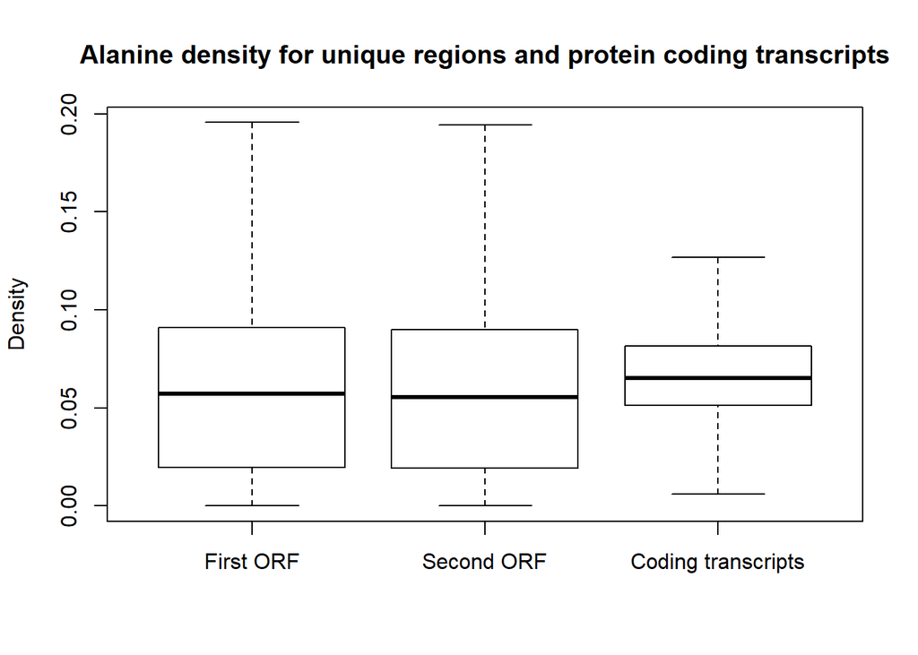

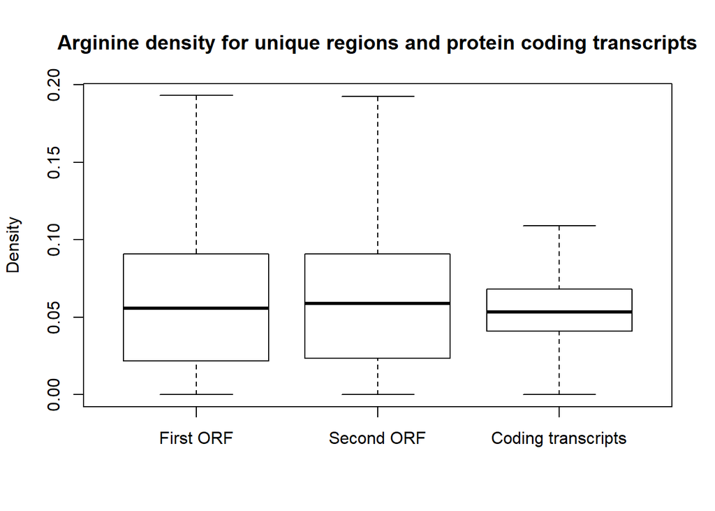

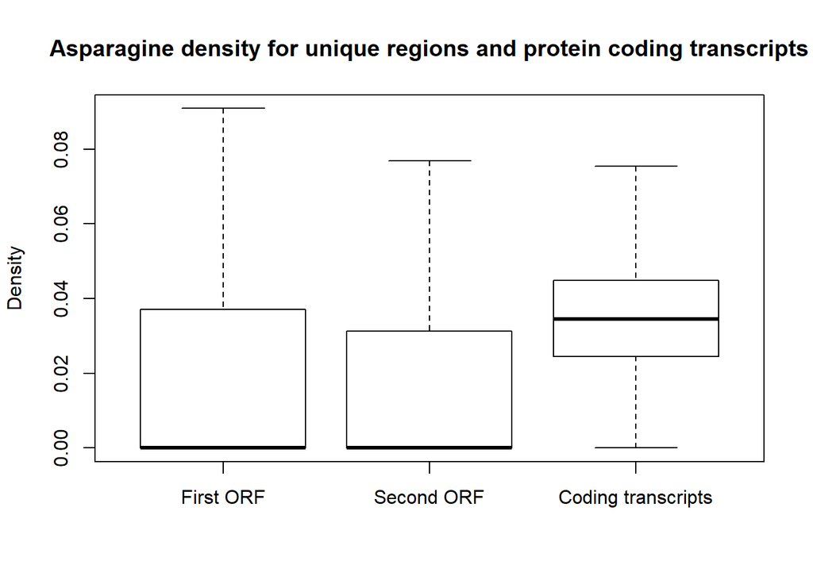

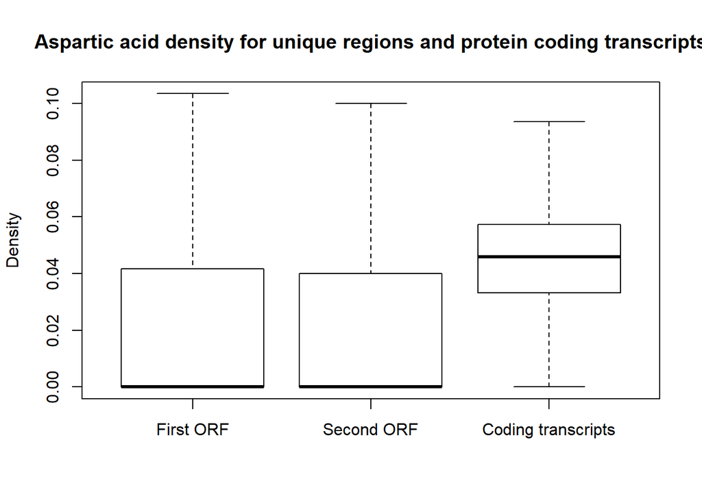

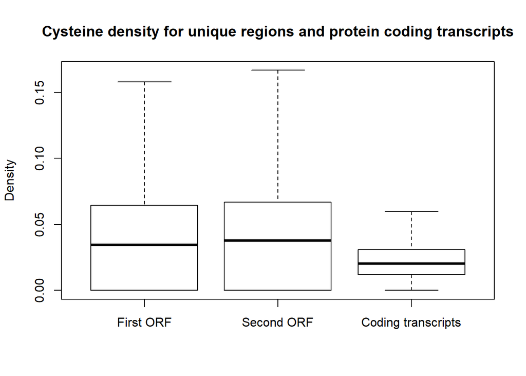

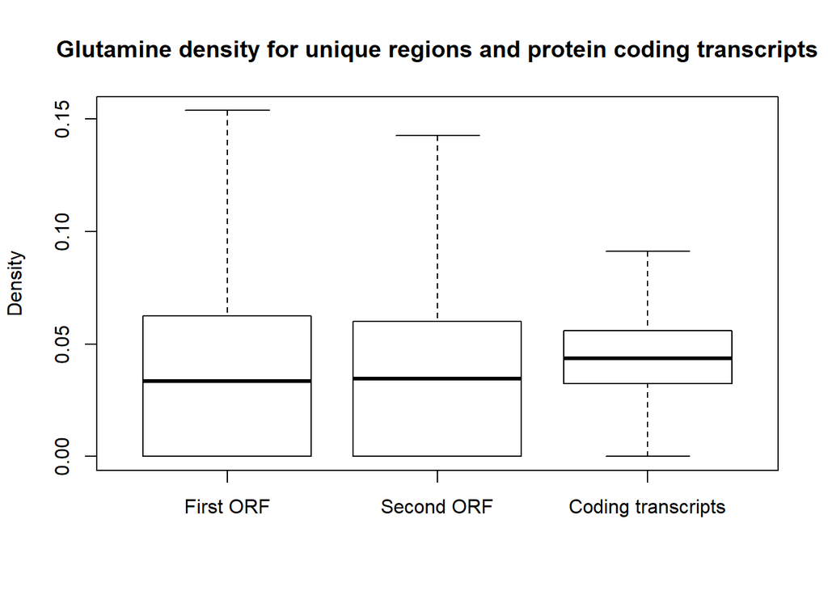

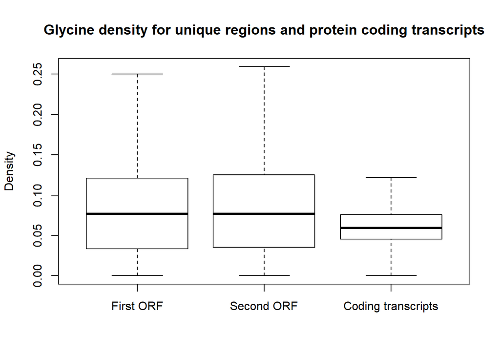

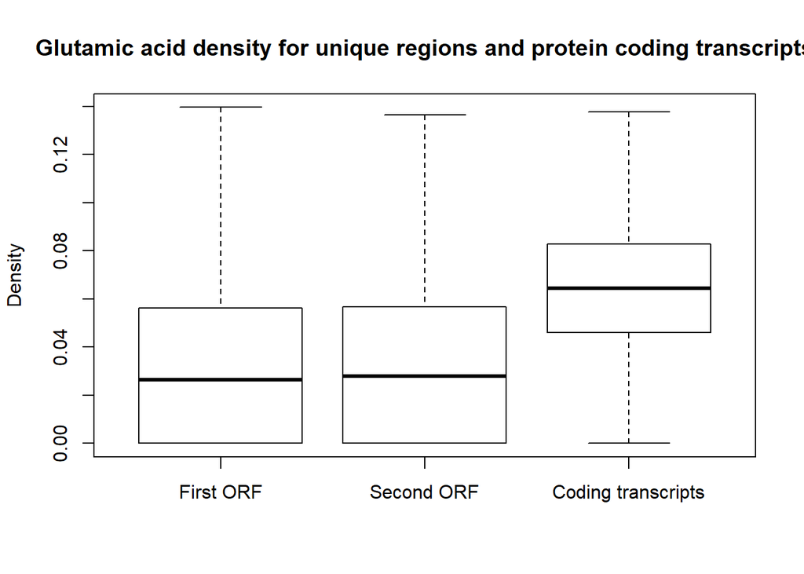

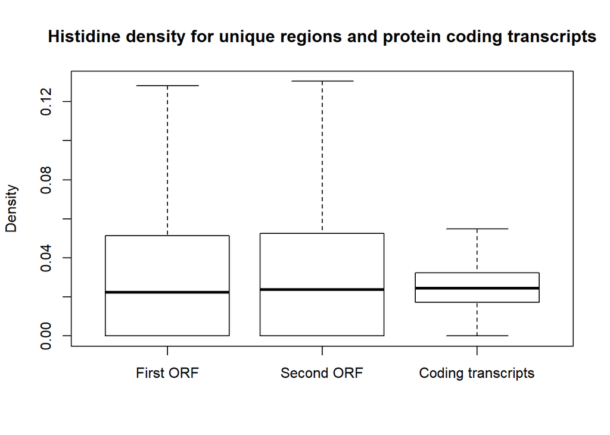

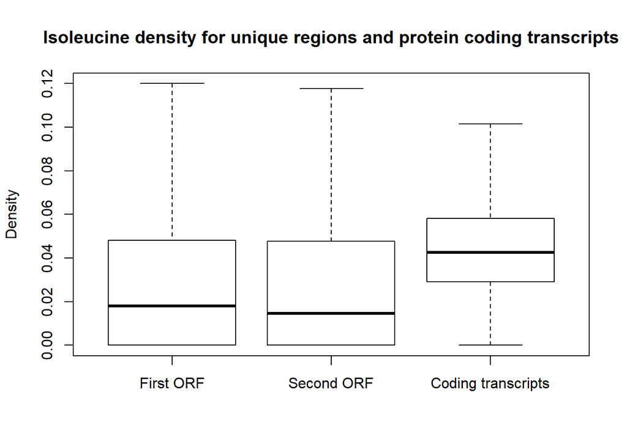

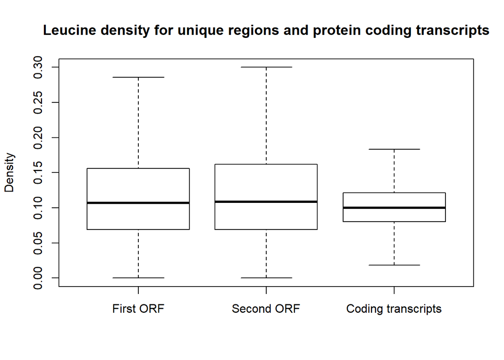

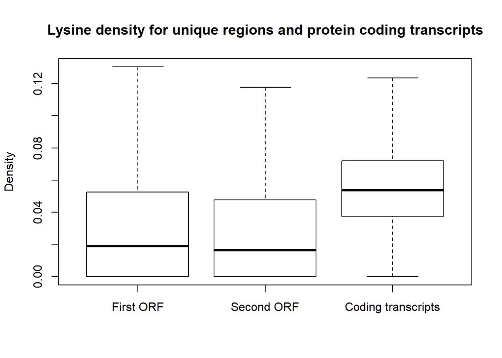

[8 more figures not shown]

### T-test between unique Protein Regions in first ORF and unique Protein Regions in second ORF:

```
## Alananine:
```

```
##
##  Welch Two Sample t-test
##
## data:  RIMousedensitiesA[[1]] and RIMousedensitiesA[[2]]
## t = 1.0549, df = 3738.2, p-value = 0.2915
## alternative hypothesis: true difference in means is not equal to 0
## 95 percent confidence interval:
##  -0.001592175  0.005301048
## sample estimates:
##  mean of x  mean of y
## 0.06319688 0.06134245
```

```
## Arginine
```

```
##
##  Welch Two Sample t-test
##
## data:  RIMousedensitiesR[[1]] and RIMousedensitiesR[[2]]
## t = -0.79431, df = 3732.8, p-value = 0.4271
## alternative hypothesis: true difference in means is not equal to 0
## 95 percent confidence interval:
##  -0.004881337  0.002066499
## sample estimates:
##  mean of x  mean of y
## 0.06245921 0.06386663
```

```
## Asparagine
```

```
##
##  Welch Two Sample t-test
##
## data:  RIMousedensitiesN[[1]] and RIMousedensitiesN[[2]]
## t = 1.955, df = 3729.8, p-value = 0.05065
## alternative hypothesis: true difference in means is not equal to 0
## 95 percent confidence interval:
##  -6.140672e-06  4.316583e-03
## sample estimates:
##  mean of x  mean of y
## 0.02209877 0.01994355
```

```
## Aspartic acid
```

```
##
##  Welch Two Sample t-test
##
## data:  RIMousedensitiesD[[1]] and RIMousedensitiesD[[2]]
## t = 1.7749, df = 3618.5, p-value = 0.076
## alternative hypothesis: true difference in means is not equal to 0
## 95 percent confidence interval:
##  -0.0002092995  0.0042093106
## sample estimates:
##  mean of x  mean of y
## 0.02558856 0.02358856
```

```
## Cysteine
```

```
##
##  Welch Two Sample t-test
##
## data:  RIMousedensitiesC[[1]] and RIMousedensitiesC[[2]]
## t = -1.4697, df = 3734.7, p-value = 0.1417
## alternative hypothesis: true difference in means is not equal to 0
## 95 percent confidence interval:
##  -0.0048843381  0.0006989556
## sample estimates:
##  mean of x  mean of y
## 0.04118871 0.04328140
```

```
## Glutamine
```

```
##
##  Welch Two Sample t-test
##
## data:  RIMousedensitiesQ[[1]] and RIMousedensitiesQ[[2]]
## t = -0.23, df = 3736, p-value = 0.8181
## alternative hypothesis: true difference in means is not equal to 0
## 95 percent confidence interval:
##  -0.002811329  0.002220972
## sample estimates:
##  mean of x  mean of y
## 0.03783361 0.03812879
```

```
## Glycine
```

```
##
##  Welch Two Sample t-test
##
## data:  RIMousedensitiesG[[1]] and RIMousedensitiesG[[2]]
## t = -0.80919, df = 3735.2, p-value = 0.4185
## alternative hypothesis: true difference in means is not equal to 0
## 95 percent confidence interval:
##  -0.006453743  0.002682853
## sample estimates:
##  mean of x  mean of y
## 0.08482520 0.08671065
```

```
## Glutamic acid
```

```
##
##  Welch Two Sample t-test
##
## data:  RIMousedensitiesE[[1]] and RIMousedensitiesE[[2]]
## t = 0.050462, df = 3700.6, p-value = 0.9598
## alternative hypothesis: true difference in means is not equal to 0
## 95 percent confidence interval:
##  -0.002705931  0.002848901
## sample estimates:
##  mean of x  mean of y
## 0.03580940 0.03573791
```

```
## Histidine
```

```
##
##  Welch Two Sample t-test
##
## data:  RIMousedensitiesH[[1]] and RIMousedensitiesH[[2]]
## t = -0.67388, df = 3736.1, p-value = 0.5004
## alternative hypothesis: true difference in means is not equal to 0
## 95 percent confidence interval:
##  -0.003138603  0.001532941
## sample estimates:
##  mean of x  mean of y
## 0.03030078 0.03110361
```

```
## Isoleucine
```

```
##
##  Welch Two Sample t-test
##
## data:  RIMousedensitiesI[[1]] and RIMousedensitiesI[[2]]
## t = 1.9829, df = 3683.3, p-value = 0.04745
## alternative hypothesis: true difference in means is not equal to 0
## 95 percent confidence interval:
##  3.065077e-05 5.425105e-03
## sample estimates:
##  mean of x  mean of y
## 0.03214161 0.02941373
```

```
## Leucine
```

```
##
##  Welch Two Sample t-test
##
## data:  RIMousedensitiesL[[1]] and RIMousedensitiesL[[2]]
## t = -0.87245, df = 3751.2, p-value = 0.383
## alternative hypothesis: true difference in means is not equal to 0
## 95 percent confidence interval:
##  -0.006735449  0.002587034
## sample estimates:
## mean of x mean of y
## 0.1158264 0.1179006
```

```
## Lysine
```

```
##
##  Welch Two Sample t-test
##
## data:  RIMousedensitiesK[[1]] and RIMousedensitiesK[[2]]
## t = 2.7093, df = 3626.2, p-value = 0.006773
## alternative hypothesis: true difference in means is not equal to 0
## 95 percent confidence interval:
##  0.001007853 0.006286178
## sample estimates:
##  mean of x  mean of y
## 0.03282275 0.02917573
```

```
## Methionine
```

```
##
##  Welch Two Sample t-test
##
## data:  RIMousedensitiesM[[1]] and RIMousedensitiesM[[2]]
## t = 0.62655, df = 3737.9, p-value = 0.531
## alternative hypothesis: true difference in means is not equal to 0
## 95 percent confidence interval:
##  -0.001585144  0.003074103
## sample estimates:
##  mean of x  mean of y
## 0.02852032 0.02777584
```

```
## Phenylalanine
```

```
##
##  Welch Two Sample t-test
##
## data:  RIMousedensitiesF[[1]] and RIMousedensitiesF[[2]]
## t = 1.339, df = 3700.1, p-value = 0.1807
## alternative hypothesis: true difference in means is not equal to 0
## 95 percent confidence interval:
##  -0.001090142  0.005786289
## sample estimates:
##  mean of x  mean of y
## 0.04455114 0.04220307
```

```
## Proline
```

```
##
##  Welch Two Sample t-test
##
## data:  RIMousedensitiesP[[1]] and RIMousedensitiesP[[2]]
## t = -1.1887, df = 3754.7, p-value = 0.2346
## alternative hypothesis: true difference in means is not equal to 0
## 95 percent confidence interval:
##  -0.006761212  0.001657166
## sample estimates:
##  mean of x  mean of y
## 0.07869143 0.08124345
```

```
## Serine
```

```
##
##  Welch Two Sample t-test
##
## data:  RIMousedensitiesS[[1]] and RIMousedensitiesS[[2]]
## t = -2.1738, df = 3750.9, p-value = 0.02978
## alternative hypothesis: true difference in means is not equal to 0
## 95 percent confidence interval:
##  -0.0090859256 -0.0004685664
## sample estimates:
## mean of x mean of y
## 0.1020210 0.1067982
```

```
## Threonine
```

```
##
##  Welch Two Sample t-test
##
## data:  RIMousedensitiesT[[1]] and RIMousedensitiesT[[2]]
## t = -0.65727, df = 3752.4, p-value = 0.511
## alternative hypothesis: true difference in means is not equal to 0
## 95 percent confidence interval:
##  -0.004011519  0.001997176
## sample estimates:
##  mean of x  mean of y
## 0.04896967 0.04997684
```

```
## Tryptophan
```

```
##
##  Welch Two Sample t-test
##
## data:  RIMousedensitiesW[[1]] and RIMousedensitiesW[[2]]
## t = -1.0814, df = 3745, p-value = 0.2796
## alternative hypothesis: true difference in means is not equal to 0
## 95 percent confidence interval:
##  -0.003467049  0.001002116
## sample estimates:
##  mean of x  mean of y
## 0.02656484 0.02779731
```

```
## Tyrosine
```

```
##
##  Welch Two Sample t-test
##
## data:  RIMousedensitiesY[[1]] and RIMousedensitiesY[[2]]
## t = 1.6406, df = 3613.3, p-value = 0.101
## alternative hypothesis: true difference in means is not equal to 0
## 95 percent confidence interval:
##  -0.0003181057  0.0035793568
## sample estimates:
##  mean of x  mean of y
## 0.01941594 0.01778532
```

```
## Valine
```

```
##
##  Welch Two Sample t-test
##
## data:  RIMousedensitiesV[[1]] and RIMousedensitiesV[[2]]
## t = 0.54317, df = 3696, p-value = 0.587
## alternative hypothesis: true difference in means is not equal to 0
## 95 percent confidence interval:
##  -0.002472441  0.004367359
## sample estimates:
##  mean of x  mean of y
## 0.06717378 0.06622632
```

### T-test between unique Protein Regions in first ORF and protein coding transcripts:

```
## Alananine:
```

```
##
##  Welch Two Sample t-test
##
## data:  RIMousedensitiesA[[1]] and RIMousedensitiesA[[3]]
## t = -3.9395, df = 1837.8, p-value = 8.47e-05
## alternative hypothesis: true difference in means is not equal to 0
## 95 percent confidence interval:
##  -0.007487483 -0.002510207
## sample estimates:
##  mean of x  mean of y
## 0.06319688 0.06819573
```

```
## Arginine
```

```
##
##  Welch Two Sample t-test
##
## data:  RIMousedensitiesR[[1]] and RIMousedensitiesR[[3]]
## t = 4.6806, df = 1834.7, p-value = 3.07e-06
## alternative hypothesis: true difference in means is not equal to 0
## 95 percent confidence interval:
##  0.003492511 0.008530319
## sample estimates:
##  mean of x  mean of y
## 0.06245921 0.05644779
```

```
## Asparagine
```

```
##
##  Welch Two Sample t-test
##
## data:  RIMousedensitiesN[[1]] and RIMousedensitiesN[[3]]
## t = -16.56, df = 1838.1, p-value < 2.2e-16
## alternative hypothesis: true difference in means is not equal to 0
## 95 percent confidence interval:
##  -0.01484140 -0.01169819
## sample estimates:
##  mean of x  mean of y
## 0.02209877 0.03536857
```

```
## Aspartic acid
```

```
##
##  Welch Two Sample t-test
##
## data:  RIMousedensitiesD[[1]] and RIMousedensitiesD[[3]]
## t = -24.06, df = 1844.3, p-value < 2.2e-16
## alternative hypothesis: true difference in means is not equal to 0
## 95 percent confidence interval:
##  -0.0224251 -0.0190447
## sample estimates:
##  mean of x  mean of y
## 0.02558856 0.04632346
```

```
## Cysteine
```

```
##
##  Welch Two Sample t-test
##
## data:  RIMousedensitiesC[[1]] and RIMousedensitiesC[[3]]
## t = 16.467, df = 1840.3, p-value < 2.2e-16
## alternative hypothesis: true difference in means is not equal to 0
## 95 percent confidence interval:
##  0.01496018 0.01900554
## sample estimates:
##  mean of x  mean of y
## 0.04118871 0.02420585
```

```
## Glutamine
```

```
##
##  Welch Two Sample t-test
##
## data:  RIMousedensitiesQ[[1]] and RIMousedensitiesQ[[3]]
## t = -8.6968, df = 1846.9, p-value < 2.2e-16
## alternative hypothesis: true difference in means is not equal to 0
## 95 percent confidence interval:
##  -0.009905195 -0.006259759
## sample estimates:
##  mean of x  mean of y
## 0.03783361 0.04591609
```

```
## Glycine
```

```
##
##  Welch Two Sample t-test
##
## data:  RIMousedensitiesG[[1]] and RIMousedensitiesG[[3]]
## t = 13.066, df = 1827.5, p-value < 2.2e-16
## alternative hypothesis: true difference in means is not equal to 0
## 95 percent confidence interval:
##  0.01870100 0.02530664
## sample estimates:
##  mean of x  mean of y
## 0.08482520 0.06282138
```

```
## Glutamic acid
```

```
##
##  Welch Two Sample t-test
##
## data:  RIMousedensitiesE[[1]] and RIMousedensitiesE[[3]]
## t = -29.173, df = 1869, p-value < 2.2e-16
## alternative hypothesis: true difference in means is not equal to 0
## 95 percent confidence interval:
##  -0.03277152 -0.02864274
## sample estimates:
##  mean of x  mean of y
## 0.03580940 0.06651653
```

```
## Histidine
```

```
##
##  Welch Two Sample t-test
##
## data:  RIMousedensitiesH[[1]] and RIMousedensitiesH[[3]]
## t = 5.2259, df = 1827.3, p-value = 1.931e-07
## alternative hypothesis: true difference in means is not equal to 0
## 95 percent confidence interval:
##  0.002808719 0.006183425
## sample estimates:
##  mean of x  mean of y
## 0.03030078 0.02580471
```

```
## Isoleucine
```

```
##
##  Welch Two Sample t-test
##
## data:  RIMousedensitiesI[[1]] and RIMousedensitiesI[[3]]
## t = -12.63, df = 1840.6, p-value < 2.2e-16
## alternative hypothesis: true difference in means is not equal to 0
## 95 percent confidence interval:
##  -0.01498033 -0.01095312
## sample estimates:
##  mean of x  mean of y
## 0.03214161 0.04510834
```

```
## Leucine
```

```
##
##  Welch Two Sample t-test
##
## data:  RIMousedensitiesL[[1]] and RIMousedensitiesL[[3]]
## t = 8.449, df = 1833.6, p-value < 2.2e-16
## alternative hypothesis: true difference in means is not equal to 0
## 95 percent confidence interval:
##  0.01095617 0.01758033
## sample estimates:
## mean of x mean of y
## 0.1158264 0.1015582
```

```
## Lysine
```

```
##
##  Welch Two Sample t-test
##
## data:  RIMousedensitiesK[[1]] and RIMousedensitiesK[[3]]
## t = -23.424, df = 1860.3, p-value < 2.2e-16
## alternative hypothesis: true difference in means is not equal to 0
## 95 percent confidence interval:
##  -0.02612559 -0.02208877
## sample estimates:
##  mean of x  mean of y
## 0.03282275 0.05692993
```

```
## Methionine
```

```
##
##  Welch Two Sample t-test
##
## data:  RIMousedensitiesM[[1]] and RIMousedensitiesM[[3]]
## t = 2.7405, df = 1848.4, p-value = 0.006193
## alternative hypothesis: true difference in means is not equal to 0
## 95 percent confidence interval:
##  0.0006695278 0.0040396562
## sample estimates:
##  mean of x  mean of y
## 0.02852032 0.02616573
```

```
## Phenylalanine
```

```
##
##  Welch Two Sample t-test
##
## data:  RIMousedensitiesF[[1]] and RIMousedensitiesF[[3]]
## t = 4.1729, df = 1825.7, p-value = 3.149e-05
## alternative hypothesis: true difference in means is not equal to 0
## 95 percent confidence interval:
##  0.002865733 0.007948428
## sample estimates:
##  mean of x  mean of y
## 0.04455114 0.03914406
```

```
## Proline
```

```
##
##  Welch Two Sample t-test
##
## data:  RIMousedensitiesP[[1]] and RIMousedensitiesP[[3]]
## t = 13.031, df = 1836.7, p-value < 2.2e-16
## alternative hypothesis: true difference in means is not equal to 0
## 95 percent confidence interval:
##  0.01676551 0.02270644
## sample estimates:
##  mean of x  mean of y
## 0.07869143 0.05895546
```

```
## Serine
```

```
##
##  Welch Two Sample t-test
##
## data:  RIMousedensitiesS[[1]] and RIMousedensitiesS[[3]]
## t = 12.496, df = 1832.9, p-value < 2.2e-16
## alternative hypothesis: true difference in means is not equal to 0
## 95 percent confidence interval:
##  0.01645330 0.02257934
## sample estimates:
##  mean of x  mean of y
## 0.10202098 0.08250466
```

```
## Threonine
```

```
##
##  Welch Two Sample t-test
##
## data:  RIMousedensitiesT[[1]] and RIMousedensitiesT[[3]]
## t = -3.8912, df = 1829.6, p-value = 0.0001033
## alternative hypothesis: true difference in means is not equal to 0
## 95 percent confidence interval:
##  -0.006352945 -0.002094951
## sample estimates:
##  mean of x  mean of y
## 0.04896967 0.05319361
```

```
## Tryptophan
```

```
##
##  Welch Two Sample t-test
##
## data:  RIMousedensitiesW[[1]] and RIMousedensitiesW[[3]]
## t = 17.244, df = 1819.3, p-value < 2.2e-16
## alternative hypothesis: true difference in means is not equal to 0
## 95 percent confidence interval:
##  0.01245381 0.01565028
## sample estimates:
##  mean of x  mean of y
## 0.02656484 0.01251279
```

```
## Tyrosine
```

```
##
##  Welch Two Sample t-test
##
## data:  RIMousedensitiesY[[1]] and RIMousedensitiesY[[3]]
## t = -11.162, df = 1836.8, p-value < 2.2e-16
## alternative hypothesis: true difference in means is not equal to 0
## 95 percent confidence interval:
##  -0.009981135 -0.006997692
## sample estimates:
##  mean of x  mean of y
## 0.01941594 0.02790536
```

```
## Valine
```

```
##
##  Welch Two Sample t-test
##
## data:  RIMousedensitiesV[[1]] and RIMousedensitiesV[[3]]
## t = 4.7392, df = 1827.4, p-value = 2.312e-06
## alternative hypothesis: true difference in means is not equal to 0
## 95 percent confidence interval:
##  0.003588478 0.008655561
## sample estimates:
##  mean of x  mean of y
## 0.06717378 0.06105176
```

### T-test between unique Protein Regions in second ORF and protein coding transcripts:

```
## Alananine:
```

```
##
##  Welch Two Sample t-test
##
## data:  RIMousedensitiesA[[2]] and RIMousedensitiesA[[3]]
## t = -5.5854, df = 1981.1, p-value = 2.654e-08
## alternative hypothesis: true difference in means is not equal to 0
## 95 percent confidence interval:
##  -0.009259633 -0.004446929
## sample estimates:
##  mean of x  mean of y
## 0.06134245 0.06819573
```

```
## Arginine
```

```
##
##  Welch Two Sample t-test
##
## data:  RIMousedensitiesR[[2]] and RIMousedensitiesR[[3]]
## t = 6.031, df = 1978.2, p-value = 1.939e-09
## alternative hypothesis: true difference in means is not equal to 0
## 95 percent confidence interval:
##  0.005006377 0.009831292
## sample estimates:
##  mean of x  mean of y
## 0.06386663 0.05644779
```

```
## Asparagine
```

```
##
##  Welch Two Sample t-test
##
## data:  RIMousedensitiesN[[2]] and RIMousedensitiesN[[3]]
## t = -20.196, df = 1982.5, p-value < 2.2e-16
## alternative hypothesis: true difference in means is not equal to 0
## 95 percent confidence interval:
##  -0.01692291 -0.01392713
## sample estimates:
##  mean of x  mean of y
## 0.01994355 0.03536857
```

```
## Aspartic acid
```

```
##
##  Welch Two Sample t-test
##
## data:  RIMousedensitiesD[[2]] and RIMousedensitiesD[[3]]
## t = -30.899, df = 2000.5, p-value < 2.2e-16
## alternative hypothesis: true difference in means is not equal to 0
## 95 percent confidence interval:
##  -0.02417788 -0.02129193
## sample estimates:
##  mean of x  mean of y
## 0.02358856 0.04632346
```

```
## Cysteine
```

```
##
##  Welch Two Sample t-test
##
## data:  RIMousedensitiesC[[2]] and RIMousedensitiesC[[3]]
## t = 19.25, df = 1984.6, p-value < 2.2e-16
## alternative hypothesis: true difference in means is not equal to 0
## 95 percent confidence interval:
##  0.01713214 0.02101897
## sample estimates:
##  mean of x  mean of y
## 0.04328140 0.02420585
```

```
## Glutamine
```

```
##
##  Welch Two Sample t-test
##
## data:  RIMousedensitiesQ[[2]] and RIMousedensitiesQ[[3]]
## t = -8.7004, df = 1992.1, p-value < 2.2e-16
## alternative hypothesis: true difference in means is not equal to 0
## 95 percent confidence interval:
##  -0.009542639 -0.006031958
## sample estimates:
##  mean of x  mean of y
## 0.03812879 0.04591609
```

```
## Glycine
```

```
##
##  Welch Two Sample t-test
##
## data:  RIMousedensitiesG[[2]] and RIMousedensitiesG[[3]]
## t = 14.753, df = 1969.6, p-value < 2.2e-16
## alternative hypothesis: true difference in means is not equal to 0
## 95 percent confidence interval:
##  0.02071360 0.02706494
## sample estimates:
##  mean of x  mean of y
## 0.08671065 0.06282138
```

```
## Glutamic acid
```

```
##
##  Welch Two Sample t-test
##
## data:  RIMousedensitiesE[[2]] and RIMousedensitiesE[[3]]
## t = -31.836, df = 2024.9, p-value < 2.2e-16
## alternative hypothesis: true difference in means is not equal to 0
## 95 percent confidence interval:
##  -0.03267463 -0.02888260
## sample estimates:
##  mean of x  mean of y
## 0.03573791 0.06651653
```

```
## Histidine
```

```
##
##  Welch Two Sample t-test
##
## data:  RIMousedensitiesH[[2]] and RIMousedensitiesH[[3]]
## t = 6.3949, df = 1969.3, p-value = 2.001e-10
## alternative hypothesis: true difference in means is not equal to 0
## 95 percent confidence interval:
##  0.003673857 0.006923948
## sample estimates:
##  mean of x  mean of y
## 0.03110361 0.02580471
```

```
## Isoleucine
```

```
##
##  Welch Two Sample t-test
##
## data:  RIMousedensitiesI[[2]] and RIMousedensitiesI[[3]]
## t = -16.957, df = 1990, p-value < 2.2e-16
## alternative hypothesis: true difference in means is not equal to 0
## 95 percent confidence interval:
##  -0.01750977 -0.01387943
## sample estimates:
##  mean of x  mean of y
## 0.02941373 0.04510834
```

```
## Leucine
```

```
##
##  Welch Two Sample t-test
##
## data:  RIMousedensitiesL[[2]] and RIMousedensitiesL[[3]]
## t = 9.6995, df = 1974.6, p-value < 2.2e-16
## alternative hypothesis: true difference in means is not equal to 0
## 95 percent confidence interval:
##  0.01303814 0.01964678
## sample estimates:
## mean of x mean of y
## 0.1179006 0.1015582
```

```
## Lysine
```

```
##
##  Welch Two Sample t-test
##
## data:  RIMousedensitiesK[[2]] and RIMousedensitiesK[[3]]
## t = -31.381, df = 2023.4, p-value < 2.2e-16
## alternative hypothesis: true difference in means is not equal to 0
## 95 percent confidence interval:
##  -0.02948870 -0.02601969
## sample estimates:
##  mean of x  mean of y
## 0.02917573 0.05692993
```

```
## Methionine
```

```
##
##  Welch Two Sample t-test
##
## data:  RIMousedensitiesM[[2]] and RIMousedensitiesM[[3]]
## t = 1.9391, df = 1993.5, p-value = 0.05264
## alternative hypothesis: true difference in means is not equal to 0
## 95 percent confidence interval:
##  -1.835018e-05  3.238575e-03
## sample estimates:
##  mean of x  mean of y
## 0.02777584 0.02616573
```

```
## Phenylalanine
```

```
##
##  Welch Two Sample t-test
##
## data:  RIMousedensitiesF[[2]] and RIMousedensitiesF[[3]]
## t = 2.5747, df = 1969.4, p-value = 0.01011
## alternative hypothesis: true difference in means is not equal to 0
## 95 percent confidence interval:
##  0.0007288942 0.0053891208
## sample estimates:
##  mean of x  mean of y
## 0.04220307 0.03914406
```

```
## Proline
```

```
##
##  Welch Two Sample t-test
##
## data:  RIMousedensitiesP[[2]] and RIMousedensitiesP[[3]]
## t = 14.539, df = 1977.1, p-value < 2.2e-16
## alternative hypothesis: true difference in means is not equal to 0
## 95 percent confidence interval:
##  0.0192816 0.0252944
## sample estimates:
##  mean of x  mean of y
## 0.08124345 0.05895546
```

```
## Serine
```

```
##
##  Welch Two Sample t-test
##
## data:  RIMousedensitiesS[[2]] and RIMousedensitiesS[[3]]
## t = 15.609, df = 1973.9, p-value < 2.2e-16
## alternative hypothesis: true difference in means is not equal to 0
## 95 percent confidence interval:
##  0.02124116 0.02734597
## sample estimates:
##  mean of x  mean of y
## 0.10679822 0.08250466
```

```
## Threonine
```

```
##
##  Welch Two Sample t-test
##
## data:  RIMousedensitiesT[[2]] and RIMousedensitiesT[[3]]
## t = -2.9574, df = 1970.1, p-value = 0.003139
## alternative hypothesis: true difference in means is not equal to 0
## 95 percent confidence interval:
##  -0.005349919 -0.001083633
## sample estimates:
##  mean of x  mean of y
## 0.04997684 0.05319361
```

```
## Tryptophan
```

```
##
##  Welch Two Sample t-test
##
## data:  RIMousedensitiesW[[2]] and RIMousedensitiesW[[3]]
## t = 19.125, df = 1959.5, p-value < 2.2e-16
## alternative hypothesis: true difference in means is not equal to 0
## 95 percent confidence interval:
##  0.01371716 0.01685187
## sample estimates:
##  mean of x  mean of y
## 0.02779731 0.01251279
```

```
## Tyrosine
```

```
##
##  Welch Two Sample t-test
##
## data:  RIMousedensitiesY[[2]] and RIMousedensitiesY[[3]]
## t = -15.649, df = 1989.7, p-value < 2.2e-16
## alternative hypothesis: true difference in means is not equal to 0
## 95 percent confidence interval:
##  -0.01138830 -0.00885178
## sample estimates:
##  mean of x  mean of y
## 0.01778532 0.02790536
```

```
## Valine
```

```
##
##  Welch Two Sample t-test
##
## data:  RIMousedensitiesV[[2]] and RIMousedensitiesV[[3]]
## t = 4.3879, df = 1971.8, p-value = 1.205e-05
## alternative hypothesis: true difference in means is not equal to 0
## 95 percent confidence interval:
##  0.002861783 0.007487338
## sample estimates:
##  mean of x  mean of y
## 0.06622632 0.06105176
```